# Chapter-05-part2-assignment

## 5H2

What about using both area and groupsize?

```r
m5h2 <- map(
  alist(
    weight ~ dnorm(mu, sigma),
    mu <- a + b.area*area + b.groupsize*groupsize,
    a <- dnorm(4.5, 2),
    b.groupsize <- dnorm(0,5),
    b.area <- dnorm(0,5),
    sigma <- dunif(0,10)),
    data=data)

precis(m5h2)
```

```
##              Mean StdDev  5.5% 94.5%
## a            4.45   0.36  3.87  5.04
## b.groupsize -0.43   0.12 -0.62 -0.24
## b.area       0.62   0.20  0.30  0.93
## sigma        1.12   0.07  1.00  1.24
```

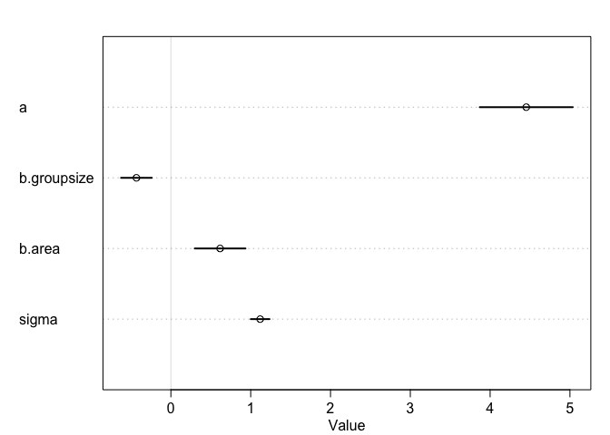

```r
plot(precis(m5h2))
```

```r
pred.data.5h2.gs <- data.frame(groupsize=seq(0,10,length.out=100),
                                      area=mean(data$area))

mu.5h2.gs <- link(m5h2,pred.data.5h2.gs,1e4)
```

[output not shown]

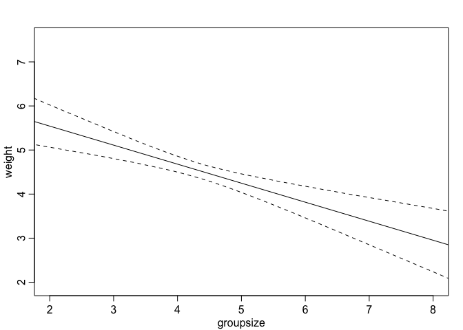

```r
mu.5h2.gs.mean <- apply(mu.5h2.gs,2,mean)
mu.5h2.gs.PI <- apply(mu.5h2.gs,2,PI)

plot(weight~groupsize,data=data,type="n")
lines(pred.data.5h2.gs$groupsize,mu.5h2.gs.mean)
lines(pred.data.5h2.gs$groupsize,mu.5h2.gs.PI[1,],lty=2)
lines(pred.data.5h2.gs$groupsize,mu.5h2.gs.PI[2,],lty=2)
```

```r
pred.data.5h2.area <- data.frame(groupsize=mean(data$groupsize),
                                      area=seq(0,10,length.out=100))

mu.5h2.area <- link(m5h2,pred.data.5h2.area,1e4)
```

[output not shown]

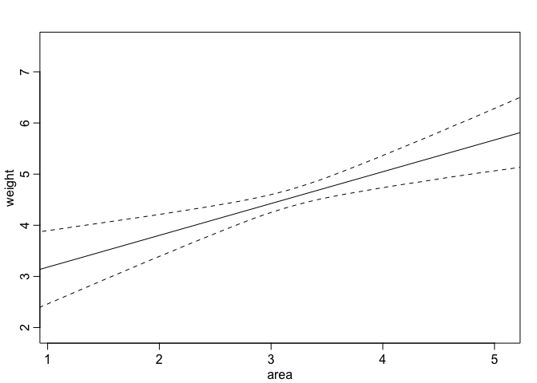

```r
mu.5h2.area.mean <- apply(mu.5h2.area,2,mean)
mu.5h2.area.PI <- apply(mu.5h2.area,2,PI)

plot(weight~area,data=data,type="n")
lines(pred.data.5h2.area$area,mu.5h2.area.mean)
lines(pred.data.5h2.area$area,mu.5h2.area.PI[1,],lty=2)
lines(pred.data.5h2.area$area,mu.5h2.area.PI[2,],lty=2)
```

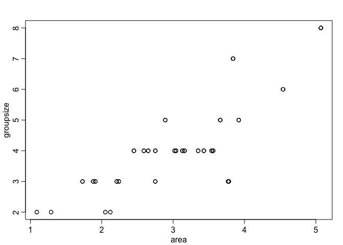

```r
plot(groupsize~area,data=data)
```

The fits much better. Why? Because groupsize and area are both correlated but affect body weight in opposite ways.

## 5H3

What about average food available in the territory?

#### Avg Food and Group Size

```r
m5h3a <- map(
  alist(
    weight ~ dnorm(mu, sigma),
    mu <- a + b.avgfood*avgfood + b.groupsize*groupsize,
    a <- dnorm(4.5, 2),
    b.groupsize <- dnorm(0,5),
    b.avgfood <- dnorm(0,5),
    sigma <- dunif(0,10)),
    data=data)

precis(m5h3a)
```

```
##              Mean StdDev  5.5% 94.5%
## a            4.19   0.42  3.52  4.86
## b.groupsize -0.54   0.15 -0.79 -0.30
## b.avgfood    3.58   1.17  1.72  5.45
## sigma        1.12   0.07  1.00  1.23
```

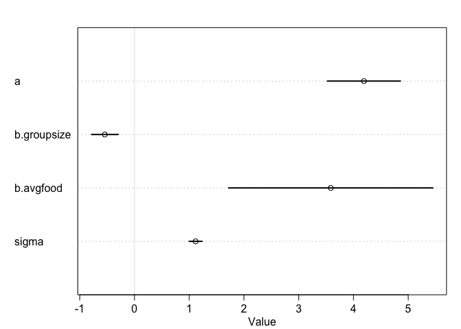

```r
plot(precis(m5h3a))
```

```r
pred.data.5h3.gs <- data.frame(groupsize=seq(0,10,length.out=100),
                                      avgfood=mean(data$avgfood))

mu.5h3.gs <- link(m5h3a,pred.data.5h3.gs,1e4)
```

[output not shown]

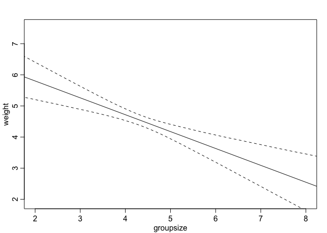

```r
mu.5h3.gs.mean <- apply(mu.5h3.gs,2,mean)
mu.5h3.gs.PI <- apply(mu.5h3.gs,2,PI)

plot(weight~groupsize,data=data,type="n")
lines(pred.data.5h3.gs$groupsize,mu.5h3.gs.mean)
lines(pred.data.5h3.gs$groupsize,mu.5h3.gs.PI[1,],lty=2)
lines(pred.data.5h3.gs$groupsize,mu.5h3.gs.PI[2,],lty=2)
```

```r
pred.data.5h3.avgfood <- data.frame(groupsize=mean(data$groupsize),
                                      avgfood=seq(0,2,length.out=100))

mu.5h3.avgfood <- link(m5h3a,pred.data.5h3.avgfood,1e4)
```

[output not shown]

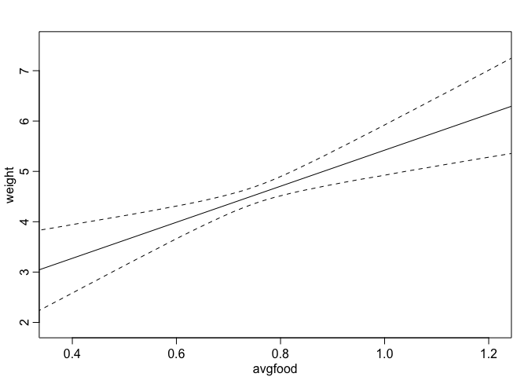

```r
mu.5h3.avgfood.mean <- apply(mu.5h3.avgfood,2,mean)
mu.5h3.avgfood.PI <- apply(mu.5h3.avgfood,2,PI)

plot(weight~avgfood,data=data,type="n")
lines(pred.data.5h3.avgfood$avgfood,mu.5h3.avgfood.mean)
lines(pred.data.5h3.avgfood$avgfood,mu.5h3.avgfood.PI[1,],lty=2)
lines(pred.data.5h3.avgfood$avgfood,mu.5h3.avgfood.PI[2,],lty=2)
```

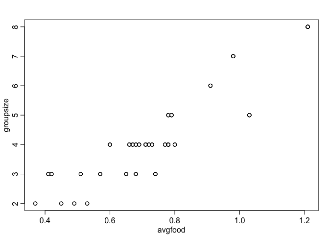

```r
plot(groupsize~avgfood,data=data)
```

```r
cor(data$groupsize,data$avgfood)
```

```
## [1] 0.9014829
```

So Avgfood and GroupSize are correlated by have opposite effects on weight so they “mask” one another. The model fits well when both are included.

#### Average Food, GroupSize, Area

```r
m5h3b <- map(
  alist(
    weight ~ dnorm(mu, sigma),
    mu <- a + b.avgfood*avgfood + b.groupsize*groupsize + b.area*area,
    a <- dnorm(4.5, 2),
    b.groupsize <- dnorm(0,5),
    b.avgfood <- dnorm(0,5),
    b.area <- dnorm(0.5),
    sigma <- dunif(0,10)),
    data=data)

precis(m5h3b)
```

```
##              Mean StdDev  5.5% 94.5%
## a            4.11   0.42  3.45  4.77
## b.groupsize -0.59   0.15 -0.84 -0.35
## b.avgfood    2.26   1.38  0.07  4.46
## b.area       0.41   0.23  0.04  0.77
## sigma        1.10   0.07  0.99  1.22
```

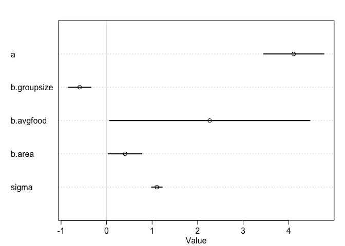

```r
plot(precis(m5h3b))
```

Now the coefficients for avgfood and area are both lower and could be 0

Question: is average food or area a better predictor of weight?

The three-predictor model isn’t very helpful because the two predictors are corelated

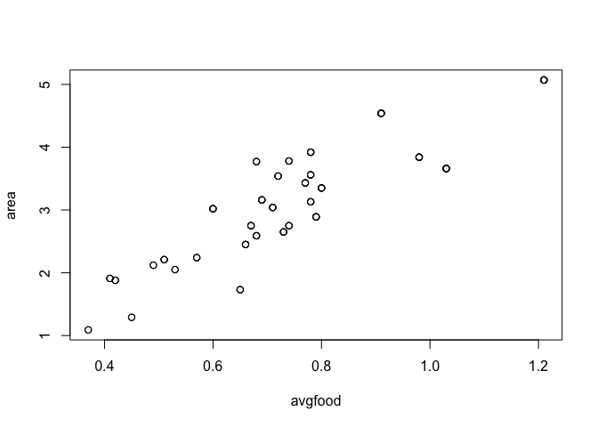

```r
plot(area ~ avgfood, data=data)
```

```r
cor(data$area, data$avgfood)
```

```
## [1] 0.8831038
```

One possiblity is to look at the sigma in the two-way models. Lowed sigma would indicate a better fit)

```r
#avgfood and groupsize
precis(m5h3a)
```

```
##              Mean StdDev  5.5% 94.5%
## a            4.19   0.42  3.52  4.86
## b.groupsize -0.54   0.15 -0.79 -0.30
## b.avgfood    3.58   1.17  1.72  5.45
## sigma        1.12   0.07  1.00  1.23
```

```r
#area and groupsize
precis(m5h2)
```

```
##              Mean StdDev  5.5% 94.5%
## a            4.45   0.36  3.87  5.04
## b.groupsize -0.43   0.12 -0.62 -0.24
## b.area       0.62   0.20  0.30  0.93
## sigma        1.12   0.07  1.00  1.24
```

They seem pretty similar to me; not sure how to ditinguish.